# FigureYa21 TCGA2table

小丫画图出品

7/21/2018

微信ID: epigenomics E-mail: epigenomics@rainbow-genome.com

本代码作者：Guangchuang Yu

小丫编辑校验

### 需求描述

TCGA临床数据直接用R代码画出三线表。

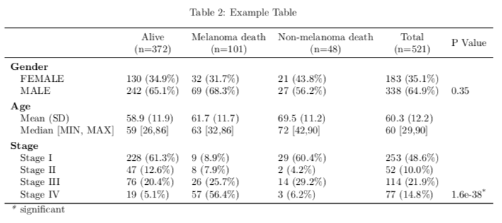

### 使用场景

输入数据是临床样品信息，例如TCGA提供的clinical information。

根据年龄、性别、种族、病毒感染、吸烟史等特征进行分类对比，可能发现疾病、癌症发病、转移、耐药跟这些特征的关系，例如发现亚洲非吸烟女性肺癌发病率高。

### 下载TCGA临床数据

如果你不需要TCGA数据，而是自己收集的数据，可以整理成像`easy_input.csv`那样的格式，跳过这步，直接进入下一步：“按列分成4组”。

```r
#source("https://bioconductor.org/biocLite.R")
#biocLite("TCGAbiolinks")
library(TCGAbiolinks)

#参数`project = `后面写你要看的癌症名称缩写
clinical <- GDCquery(project = "TCGA-LIHC",
                  data.category = "Clinical",
                  file.type = "xml")
GDCdownload(clinical)
cliquery <- GDCprepare_clinic(clinical, clinical.info = "patient")
colnames(cliquery)[1] <- "Tumor_Sample_Barcode"
write.csv(cliquery,"easy_input.csv")
```

### 按列分成4组

即`Alive`、`Dead with tumor`、`Dead tumor free`、`Total`。

```r
library(dplyr)
x = read.csv("easy_input.csv")

#%>%，是管道操作符，将上一个函数的输出作为下一个函数的输入
#其实用for循环一个一个嵌套也能实现，就是写起来太烦
#用dplyr包的管道操作符，无论读写都变得清晰容易了

#挑出生存状态是“Alive”的行
x1 = x %>% filter(vital_status == "Alive")
#挑出生存状态是“Dead”并且有tumor的行
x2 = x %>% filter(vital_status == "Dead" & person_neoplasm_cancer_status == "WITH TUMOR")
x3 = x %>% filter(vital_status == "Dead" & person_neoplasm_cancer_status == "TUMOR FREE")

#把没信息的行去掉，用于算总数
xx = x %>% filter(vital_status != "" & person_neoplasm_cancer_status != "")
```

### 按项细分

#### 性别

```r
#还记得前面提取的x1是生存状态是“Alive”的行，把这些行按性别分组
s1 = x1 %>% group_by(gender) %>% summarise(alive=n())
s1
```

```
## # A tibble: 2 x 2
##   gender alive
##   <fct>  <int>
## 1 FEMALE    84
## 2 MALE     202
```

```r
s2 = x2 %>% group_by(gender) %>% summarise(tumor=n())
s3 = x3 %>% group_by(gender) %>% summarise(tumor_free=n())

#依次合并s1、s2、s3
sex = full_join(s1, s2, by='gender') %>% full_join(s3, by='gender') %>% as.data.frame
sex
```

```
##   gender alive tumor tumor_free
## 1 FEMALE    84    25         10
## 2   MALE   202    28         18
```

```r
rn = sex[,1]#取出第一列，后面作为行名
sex = sex[,-1]#先把不需要计算的第一列删除

#计算p value
sex.p = chisq.test(sex)$p.value
print(sex.p)
```

```
## [1] 0.03661159
```

```r
#算总数
sex$total = rowSums(sex)
cs = colSums(sex)

#算百分比、写到括号里
#用sprintf格式化为小数点后保留1位，加上百分号
#用paste0加到个数后面，默认是sep=""，比paste代码更简洁
sex <- rbind(paste0(sex[1,], " (", sprintf("%1.1f\\%%", sex[1,]/cs*100), ")"),
    paste0(sex[2,], " (", sprintf("%1.1f\\%%", sex[2,]/cs*100), ")"))

#加上行名、列名
rownames(sex) = rn
colnames(sex) = paste0(c("Alive", "Dead with tumor", "Dead tumor free", "Total"),
                "\n(n=", cs, ")")
print(sex)
```

```
##        Alive\n(n=286)  Dead with tumor\n(n=53) Dead tumor free\n(n=28)
## FEMALE "84 (29.4\\%)"  "25 (47.2\\%)"          "10 (35.7\\%)"
## MALE   "202 (70.6\\%)" "28 (52.8\\%)"          "18 (64.3\\%)"
##        Total\n(n=367)
## FEMALE "119 (32.4\\%)"
## MALE   "248 (67.6\\%)"
```

#### 年龄

```r
#先写个函数，用到dplyr包
#有些年龄数据缺失，需要去掉
age_stats <- function(x) {
   res <- x %>% summarise(age = round(mean(age_at_initial_pathologic_diagnosis,na.rm = T), 1),
                sd=round(sd(age_at_initial_pathologic_diagnosis,na.rm = T), 1),
                median=round(median(age_at_initial_pathologic_diagnosis,na.rm = T), 1),
                min=round(min(age_at_initial_pathologic_diagnosis,na.rm = T), 1),
                max=round(max(age_at_initial_pathologic_diagnosis,na.rm = T), 1)
                )
   c("Mean (SD)" = with(res, paste0(age, " (", sd, ")")),
       "Median [MIN, MAX]" = with(res, paste0(median, " [", min, ",", max, "]"))#,
   )
}

a1 = age_stats(x1)
a2 = age_stats(x2)
a3 = age_stats(x3)
aa = age_stats(xx)
#依次合并a1、a2、a3、aa
age = cbind(a1, a2) %>% cbind(a3) %>% cbind(aa)

colnames(age) = colnames(sex)
print(age)
```

```
##                   Alive\n(n=286) Dead with tumor\n(n=53)
## Mean (SD)         "58 (13.3)"    "63.1 (13.1)"
## Median [MIN, MAX] "60 [16,84]"   "64 [23,90]"
##                   Dead tumor free\n(n=28) Total\n(n=367)
## Mean (SD)         "67.1 (11.3)"           "59.5 (13.1)"
## Median [MIN, MAX] "67.5 [35,83]"          "61 [16,90]"
```

#### Stage

```r
stage_stats <- function(x) {
    x %>% filter(stage_event_pathologic_stage != "") %>%
        group_by(stage_event_pathologic_stage) %>% summarise(stage = n())
}

sg1 = stage_stats(x1)
sg2 = stage_stats(x2)
sg3 = stage_stats(x3)
sgx = stage_stats(xx)
sg = full_join(sg1, sg2, by="stage_event_pathologic_stage") %>%
    full_join(sg3, by="stage_event_pathologic_stage") %>%
    full_join(sgx, by="stage_event_pathologic_stage") %>%
    as.data.frame

rownames(sg) = sg[,1]
sg = sg[,-1]
colnames(sg) = colnames(sex)

print(sg)
```

```
##            Alive\n(n=286) Dead with tumor\n(n=53) Dead tumor free\n(n=28)
## Stage I               135                      19                      17
## Stage II               71                       7                       6
## Stage III               1                       1                      NA
## Stage IIIA             51                      10                       4
## Stage IIIB              6                       2                      NA
## Stage IIIC              8                       1                      NA
## Stage IV                1                      NA                      NA
## Stage IVA               1                      NA                      NA
## Stage IVB              NA                       2                      NA
##            Total\n(n=367)
## Stage I               164
## Stage II               78
## Stage III               2
## Stage IIIA             62
## Stage IIIB              8
## Stage IIIC              9
## Stage IV                1
## Stage IVA              NA
## Stage IVB               2
```

```r
# chisq test
# total列不用于计算，删掉它
sgx <- sg[, -4]
# 有些stage在分组里没人，不用于计算p value
sgx <- sgx[!apply(sgx, 1, anyNA),]
# 计算p value
sg.p = chisq.test(sgx)$p.value

# NA的啥都不打印
sgv2 = lapply(1:nrow(sg), function(i) ifelse(is.na(sg[i,]), "",
    paste0(sg[i,], " (", sprintf("%1.1f\\%%", sg[i,]/cs * 100), ")"))) %>%
    do.call(rbind, .)
#或者用下面这种，打印“NA”字样
#sgv2 = lapply(1:nrow(sg), function(i) ifelse(is.na(sg[i,]), NA,
#    paste0(sg[i,], " (", sprintf("%1.1f\\%%", sg[i,]/cs * 100), ")"))) %>%
#    do.call(rbind, .)

rownames(sgv2) = rownames(sg)
colnames(sgv2) = colnames(sg)
print(sgv2)
```

```
##            Alive\n(n=286)  Dead with tumor\n(n=53) Dead tumor free\n(n=28)
## Stage I    "135 (47.2\\%)" "19 (35.8\\%)"          "17 (60.7\\%)"
## Stage II   "71 (24.8\\%)"  "7 (13.2\\%)"           "6 (21.4\\%)"
## Stage III  "1 (0.3\\%)"    "1 (1.9\\%)"            ""
## Stage IIIA "51 (17.8\\%)"  "10 (18.9\\%)"          "4 (14.3\\%)"
## Stage IIIB "6 (2.1\\%)"    "2 (3.8\\%)"            ""
## Stage IIIC "8 (2.8\\%)"    "1 (1.9\\%)"            ""
## Stage IV   "1 (0.3\\%)"    ""                      ""
## Stage IVA  "1 (0.3\\%)"    ""                      ""
## Stage IVB  ""              "2 (3.8\\%)"            ""
##            Total\n(n=367)
## Stage I    "164 (44.7\\%)"
## Stage II   "78 (21.3\\%)"
## Stage III  "2 (0.5\\%)"
## Stage IIIA "62 (16.9\\%)"
## Stage IIIB "8 (2.2\\%)"
## Stage IIIC "9 (2.5\\%)"
## Stage IV   "1 (0.3\\%)"
## Stage IVA  ""
## Stage IVB  "2 (0.5\\%)"
```

#### 合并

```r
res = rbind(sex, age) %>% rbind(sgv2) %>% as.data.frame
print(res)
```

```
##                   Alive\n(n=286) Dead with tumor\n(n=53)
## FEMALE              84 (29.4\\%)            25 (47.2\\%)
## MALE               202 (70.6\\%)            28 (52.8\\%)
## Mean (SD)              58 (13.3)             63.1 (13.1)
## Median [MIN, MAX]     60 [16,84]              64 [23,90]
## Stage I            135 (47.2\\%)            19 (35.8\\%)
## Stage II            71 (24.8\\%)             7 (13.2\\%)
## Stage III             1 (0.3\\%)              1 (1.9\\%)
## Stage IIIA          51 (17.8\\%)            10 (18.9\\%)
## Stage IIIB            6 (2.1\\%)              2 (3.8\\%)
## Stage IIIC            8 (2.8\\%)              1 (1.9\\%)
## Stage IV              1 (0.3\\%)
## Stage IVA             1 (0.3\\%)
## Stage IVB                                     2 (3.8\\%)
##                   Dead tumor free\n(n=28) Total\n(n=367)
## FEMALE                       10 (35.7\\%)  119 (32.4\\%)
## MALE                         18 (64.3\\%)  248 (67.6\\%)
## Mean (SD)                     67.1 (11.3)    59.5 (13.1)
## Median [MIN, MAX]            67.5 [35,83]     61 [16,90]
## Stage I                      17 (60.7\\%)  164 (44.7\\%)
## Stage II                      6 (21.4\\%)   78 (21.3\\%)
## Stage III                                     2 (0.5\\%)
## Stage IIIA                    4 (14.3\\%)   62 (16.9\\%)
## Stage IIIB                                    8 (2.2\\%)
## Stage IIIC                                    9 (2.5\\%)
## Stage IV                                      1 (0.3\\%)
## Stage IVA
## Stage IVB                                     2 (0.5\\%)
```

### 生成表格

用`kableExtra`包生成好看的html表格

```r
#install.packages("kableExtra")
require(kableExtra)
if (knitr:::is_html_output()) {
    cn = sub("\n", "<br>", colnames(res))
} else if (knitr:::is_latex_output()) {
    usepackage_latex('makecell')
    usepackage_latex('booktabs')
    cn = linebreak(colnames(res), align="c")
}

#如果你不用knit，而是复制粘贴代码，需要运行下面这行
#cn = colnames(res)

res %>%
    kable(booktabs = T, escape = F, caption = "Example Table",
        col.names = cn) %>%
    kable_styling(c("striped", "scale_down")) %>%
    group_rows("Gender*", 1, 2) %>% #根据p value手动加*
    group_rows("Age", 3, 4) %>% #根据具体分组数设置行数，例如这里年龄是两行，这里写3和4
    group_rows("Stage", 5, 13) %>% #根据具体分组数设置行数，例如从5到13都是stage，这里写5和13
    footnote(general = "significant",
             #general = paste("P-value =", sg.p), #或者用这行直接打印p value
             general_title = "*: ",
             footnote_as_chunk = T, title_format = "italic")
```

Example Table

|  | Alive (n=286) | Dead with tumor (n=53) | Dead tumor free (n=28) | Total (n=367) |
| --- | --- | --- | --- | --- |
| **Gender*** |  |  |  |  |
| FEMALE | 84 (29.4%) | 25 (47.2%) | 10 (35.7%) | 119 (32.4%) |
| MALE | 202 (70.6%) | 28 (52.8%) | 18 (64.3%) | 248 (67.6%) |
| **Age** |  |  |  |  |
| Mean (SD) | 58 (13.3) | 63.1 (13.1) | 67.1 (11.3) | 59.5 (13.1) |
| Median [MIN, MAX] | 60 [16,84] | 64 [23,90] | 67.5 [35,83] | 61 [16,90] |
| **Stage** |  |  |  |  |
| Stage I | 135 (47.2%) | 19 (35.8%) | 17 (60.7%) | 164 (44.7%) |
| Stage II | 71 (24.8%) | 7 (13.2%) | 6 (21.4%) | 78 (21.3%) |
| Stage III | 1 (0.3%) | 1 (1.9%) |  | 2 (0.5%) |
| Stage IIIA | 51 (17.8%) | 10 (18.9%) | 4 (14.3%) | 62 (16.9%) |
| Stage IIIB | 6 (2.1%) | 2 (3.8%) |  | 8 (2.2%) |
| Stage IIIC | 8 (2.8%) | 1 (1.9%) |  | 9 (2.5%) |
| Stage IV | 1 (0.3%) |  |  | 1 (0.3%) |
| Stage IVA | 1 (0.3%) |  |  |  |
| Stage IVB |  | 2 (3.8%) |  | 2 (0.5%) |

*: significant

```r
#下面要把P value加到最后一列

#如果p值太小，不想打太多位，round一下位数又变成0，就用科学记数
#例如用sprintf("%1.1e", sex.p)替换round(sex.p, 3)

#哪个P value显著，就在哪个p value后面加上*
#就像这样：“paste0(round(sg.p, 3), footnote_marker_symbol(1))”

res[["P Value"]] = c("", paste0(round(sex.p, 3), footnote_marker_symbol(1)), ## sex
                 rep("", 2), ## age
                 rep("", nrow(sg)-1), round(sg.p, 3) ## stage
                 )
cn <- c(cn, "P Value") #加个列名

res %>%
    kable(booktabs = T, escape = F, caption = "Example Table",
        col.names = cn) %>%
    kable_styling(c("striped", "scale_down")) %>%
    group_rows("Gender", 1, 2) %>% #根据具体分组数设置行数，例如性别是两行，这里写1和2
    group_rows("Age", 3, 4) %>% #根据具体分组数设置行数，例如这里年龄是两行，这里写3和4
    group_rows("Stage", 5, 13) %>% #根据具体分组数设置行数，例如从5到13都是stage，这里写5和13
    footnote(general = "significant",
             #general = paste("P-value =", sg.p), #或者用这行直接打印p value
            general_title = "*",
            footnote_as_chunk = T, title_format = "italic")
```

Example Table

|  | Alive (n=286) | Dead with tumor (n=53) | Dead tumor free (n=28) | Total (n=367) | P Value |
| --- | --- | --- | --- | --- | --- |
| **Gender** |  |  |  |  |  |
| FEMALE | 84 (29.4%) | 25 (47.2%) | 10 (35.7%) | 119 (32.4%) |  |
| MALE | 202 (70.6%) | 28 (52.8%) | 18 (64.3%) | 248 (67.6%) | 0.037* |
| **Age** |  |  |  |  |  |
| Mean (SD) | 58 (13.3) | 63.1 (13.1) | 67.1 (11.3) | 59.5 (13.1) |  |
| Median [MIN, MAX] | 60 [16,84] | 64 [23,90] | 67.5 [35,83] | 61 [16,90] |  |
| **Stage** |  |  |  |  |  |
| Stage I | 135 (47.2%) | 19 (35.8%) | 17 (60.7%) | 164 (44.7%) |  |
| Stage II | 71 (24.8%) | 7 (13.2%) | 6 (21.4%) | 78 (21.3%) |  |
| Stage III | 1 (0.3%) | 1 (1.9%) |  | 2 (0.5%) |  |
| Stage IIIA | 51 (17.8%) | 10 (18.9%) | 4 (14.3%) | 62 (16.9%) |  |
| Stage IIIB | 6 (2.1%) | 2 (3.8%) |  | 8 (2.2%) |  |
| Stage IIIC | 8 (2.8%) | 1 (1.9%) |  | 9 (2.5%) |  |
| Stage IV | 1 (0.3%) |  |  | 1 (0.3%) |  |
| Stage IVA | 1 (0.3%) |  |  |  |  |
| Stage IVB |  | 2 (3.8%) |  | 2 (0.5%) | 0.574 |

* significant

### 生成pdf格式的表格

1. 把第5行换成`output: latex_document`
2. 删除本文档中所有中文，保存为`FigureYa21TCGA2table_latex.Rmd`
3. 点击`Knit`，会生成`FigureYa21TCGA2table_latex.tex`文件
4. 通过复制粘贴运行下面两行，就会输出pdf格式的文件

```r
library(tools)
texi2pdf("FigureYa21TCGA2table_latex.tex")
```

注：如果要表格页不显示代码，就把第224行换成这句：“```{r eval=T, echo = F}”